# Rohan Bandaru - Ch1 Final Submission GOAT Project

This is an R notebook. It is my first time using R and I learned a lot about practical application of statistics. I also used Python for some pre-processing (filtering csv files) allowing me to use hundreds of data points.

# Intro

I chose tennis as my sport and listed the following players as contenders for the “Greates Of All Time” title.

Roger Federer -SUI Novak Djokovic -SRB Rafael Nadal -ESP Ivan Lendl -USA Jimmy Connors -USA Pete Sampras -USA John McEnroe -USA Bjorn Borg -SWE Andre Agassi -USA Borris Becker -GER

There are a few things I wanted to consider when choosing the GOAT:

- game skill
- how long they were good
- consistency (inter-game variability)

These qualities are what led me to choose the statistics below:

No. Grand Slams Won, No. Big Titles Won (GS, TF, M), Games Played, Games Won, Matches Played, Matches Won, Weeks at #1, Hard Court Win %, Clay Court Win %, Grass Court Win %, Carpet Court Win %, Elo (rating), Match time *I didn’t use all these statistics in my final analysis because there was no easy way I could pull come of them off the website

The reason why I am not doing win rate or win/loss ratio, is because I believe that the title of GOAT should be based on the total amount of wins and titles accumulated over time. A player may win all his matches but if he only plays in one title, he should not become the GOAT.

I also gathered the raw data (score, surface, and duration) from every game they ever played (that was recorded).

To compare the players, I will take a weighted combination of their Z-scores for each statistic

Source: https://www.ultimatetennisstatistics.com/

# Setting Up Environment

```r
setwd("~/Documents/AP Stats")
```

# Statistic 1 - Number of Grand Slam Titles Won

Grand Slam Titles are the highest level of competition in tennis: US Open, Australian Open, French Open(Roland Garros), and Wimbledon.

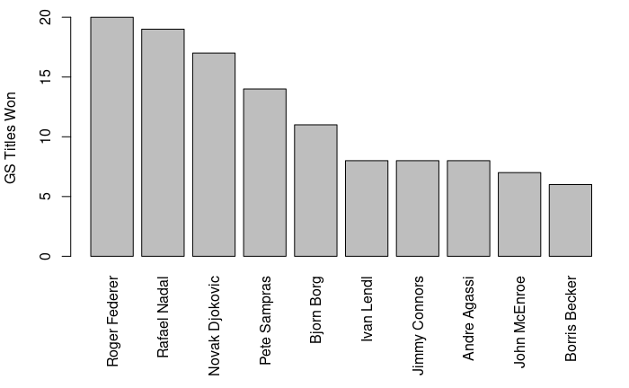

```r
overallstats <- read.csv(file = 'overallstats.csv')

grandslams <- overallstats[["GrandSlams"]]
names(grandslams) <- overallstats[["PlayerName"]]

par(mar=c(7.5, 4.1, 1, 1))
barplot(sort(grandslams, decreasing = TRUE), las=3, ylab="GS Titles Won")
```

Calculate Z-Scores (Normalize Distribution)

```r
m = mean(grandslams)
stdv = sd(grandslams)

print(paste0("Mean GS Titles Won: ", m))
```

```
[1] "Mean GS Titles Won: 11.8"
```

```r
print(paste0("Standard Deviation: ", stdv))
```

```
[1] "Standard Deviation: 5.28730134903956"
```

```r
print("Z-scores:")
```

```
[1] "Z-scores:"
```

```r
# zs = (grandslams - m)/stdv
# summary(zs)
zscores_gs = scale(grandslams)
print(zscores_gs)
```

```
                     [,1]
Roger Federer   1.5508857
Novak Djokovic  0.9834885
Rafael Nadal    1.3617533
Ivan Lendl     -0.7187031
Jimmy Connors  -0.7187031
Pete Sampras    0.4160913
John McEnroe   -0.9078355
Bjorn Borg     -0.1513059
Andre Agassi   -0.7187031
Borris Becker  -1.0969679
attr(,"scaled:center")
[1] 11.8
attr(,"scaled:scale")
[1] 5.287301
```

Total GS Titles Won In The Entire Group

```r
stem(grandslams)
```

```
  The decimal point is 1 digit(s) to the right of the |

  0 | 67888
  1 | 14
  1 | 79
  2 | 0
```

A lot of the players have below 10 titles, and it quickly narrows down to the few top-players.

# Statistic 2 - Number of Big Titles Won

Big Titles include Grand Slams(Majors), Tour Finals, Olympic Titles, etc.

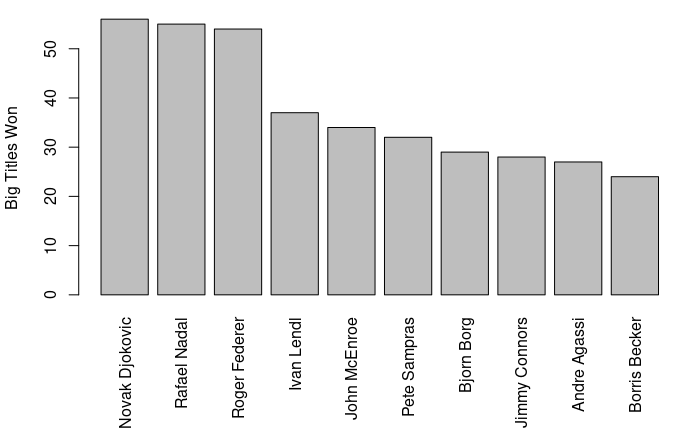

```r
bigtitles <- overallstats[["BigTitles"]]
names(bigtitles) <- overallstats[["PlayerName"]]

par(mar=c(7, 4.1, 1, 1))
barplot(sort(bigtitles, decreasing = TRUE), las=3, ylab="Big Titles Won")
```

Calculate Z-Scores (Normalize Distribution)

```r
m = mean(bigtitles)
stdv = sd(bigtitles)

print(paste0("Mean Big Titles Won: ", m))
```

```
[1] "Mean Big Titles Won: 37.6"
```

```r
print(paste0("Standard Deviation: ", stdv))
```

```
[1] "Standard Deviation: 12.5538838611802"
```

```r
print("Z-scores:")
```

```
[1] "Z-scores:"
```

```r
zscores_bt = scale(bigtitles)
print(zscores_bt)
```

```
                      [,1]
Roger Federer   1.30636863
Novak Djokovic  1.46568187
Rafael Nadal    1.38602525
Ivan Lendl     -0.04779397
Jimmy Connors  -0.76470359
Pete Sampras   -0.44607709
John McEnroe   -0.28676384
Bjorn Borg     -0.68504696
Andre Agassi   -0.84436021
Borris Becker  -1.08333008
attr(,"scaled:center")
[1] 37.6
attr(,"scaled:scale")
[1] 12.55388
```

# Statistic 3 - Games Won

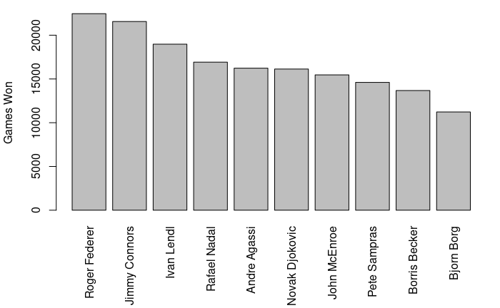

```r
gameswon <- overallstats[["GamesWon"]]
names(gameswon) <- overallstats[["PlayerName"]]

par(mar=c(7, 4.1, 1, 1))
barplot(sort(gameswon, decreasing = TRUE), las=3, ylab="Games Won")
```

Calculate Z-Scores (Normalize Distribution)

```r
m = mean(gameswon)
stdv = sd(gameswon)

print(paste0("Mean Games Won: ", m))
```

```
[1] "Mean Games Won: 16725.7"
```

```r
print(paste0("Standard Deviation: ", stdv))
```

```
[1] "Standard Deviation: 3457.14455230839"
```

```r
print("Z-scores:")
```

```
[1] "Z-scores:"
```

```r
zscores_gw = scale(gameswon)
print(zscores_gw)
```

```
                     [,1]
Roger Federer   1.6581025
Novak Djokovic -0.1711528
Rafael Nadal    0.0559132
Ivan Lendl      0.6506236
Jimmy Connors   1.3992183
Pete Sampras   -0.6125576
John McEnroe   -0.3640866
Bjorn Borg     -1.5908215
Andre Agassi   -0.1430950
Borris Becker  -0.8821442
attr(,"scaled:center")
[1] 16725.7
attr(,"scaled:scale")
[1] 3457.145
```

# Statistic 4 - Matches Won

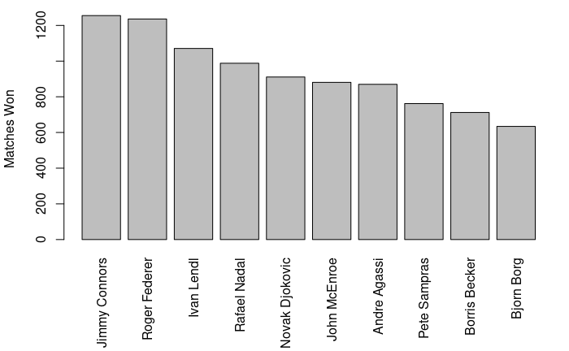

```r
matcheswon <- overallstats[["MatchesWon"]]
names(matcheswon) <- overallstats[["PlayerName"]]

par(mar=c(7, 4.1, 1, 1))
barplot(sort(matcheswon, decreasing = TRUE), las=3, ylab="Matches Won")
```

Calculate Z-Scores (Normalize Distribution)

```r
m = mean(matcheswon)
stdv = sd(matcheswon)

print(paste0("Mean Matches Won: ", m))
```

```
[1] "Mean Matches Won: 932"
```

```r
print(paste0("Standard Deviation: ", stdv))
```

```
[1] "Standard Deviation: 208.75078176833"
```

```r
print("Z-scores:")
```

```
[1] "Z-scores:"
```

```r
zscores_mw = scale(matcheswon)
print(zscores_mw)
```

```
                     [,1]
Roger Federer   1.4562820
Novak Djokovic -0.1005984
Rafael Nadal    0.2682625
Ivan Lendl      0.6658658
Jimmy Connors   1.5472996
Pete Sampras   -0.8143682
John McEnroe   -0.2443105
Bjorn Borg     -1.4275396
Andre Agassi   -0.2970049
Borris Becker  -1.0538883
attr(,"scaled:center")
[1] 932
attr(,"scaled:scale")
[1] 208.7508
```

# Statistic 5 - Weeks At #1 Rank

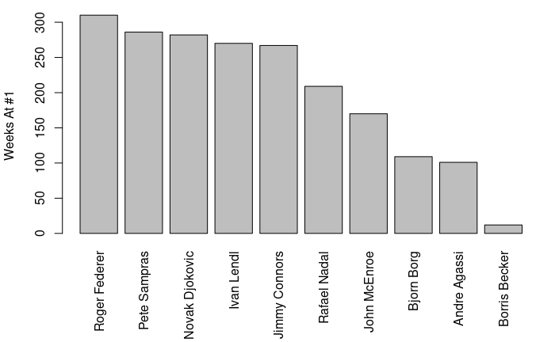

```r
weeksatone <- overallstats[["WeeksAt1"]]
names(weeksatone) <- overallstats[["PlayerName"]]

par(mar=c(7, 4.1, 1, 1))
barplot(sort(weeksatone, decreasing = TRUE), las=3, ylab="Weeks At #1")
```

Calculate Z-Scores (Normalize Distribution)

```r
m = mean(weeksatone)
stdv = sd(weeksatone)

print(paste0("Mean Weeks At The #1 Rank: ", m))
```

```
[1] "Mean Weeks At The #1 Rank: 201.6"
```

```r
print(paste0("Standard Deviation: ", stdv))
```

```
[1] "Standard Deviation: 99.9946665244369"
```

```r
print("Z-scores:")
```

```
[1] "Z-scores:"
```

```r
zscores_wao = scale(weeksatone)
print(zscores_wao)
```

```
                      [,1]
Roger Federer   1.08405782
Novak Djokovic  0.80404288
Rafael Nadal    0.07400395
Ivan Lendl      0.68403648
Jimmy Connors   0.65403488
Pete Sampras    0.84404502
John McEnroe   -0.31601685
Bjorn Borg     -0.92604939
Andre Agassi   -1.00605366
Borris Becker  -1.89610113
attr(,"scaled:center")
[1] 201.6
attr(,"scaled:scale")
[1] 99.99467
```

# Statistic 6 - Average Game Score Difference (Variability)

## Roger Federer

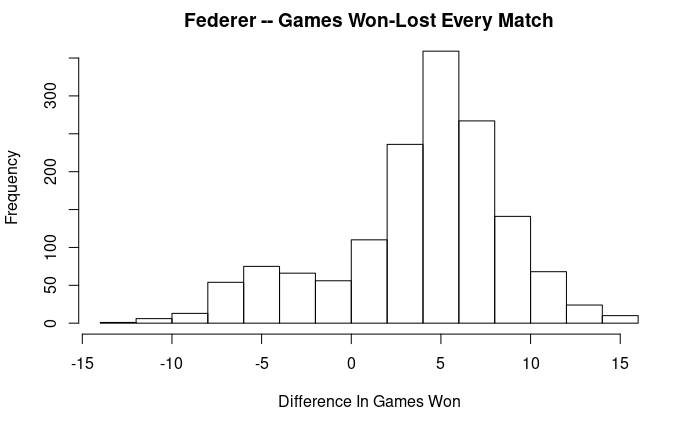

```r
RFmatches <- read.csv(file = 'Tennis Player Matches/1RFMatches.csv')
gamedifferencepermatch <- RFmatches[["GameDifference"]]
hist(gamedifferencepermatch, xlab = "Difference In Games Won", main = "Federer -- Games Won-Lost Every Match", breaks = 15)
```

Calculate “Variability” And Notice Distribution Shape

```r
m = mean(gamedifferencepermatch)
stdv = sd(gamedifferencepermatch)

summary(gamedifferencepermatch)
```

```
   Min. 1st Qu.  Median    Mean 3rd Qu.    Max.
-14.000   2.000   5.000   4.328   7.000  16.000
```

```r
print(paste0("Standard Deviation: ", stdv))
```

```
[1] "Standard Deviation: 4.80976431016085"
```

## Novak Djokovic

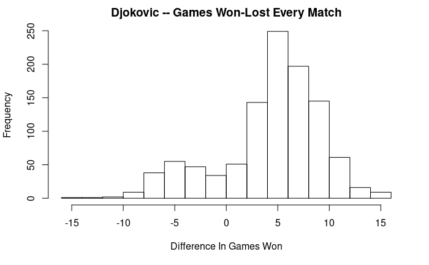

```r
NDmatches <- read.csv(file = 'Tennis Player Matches/2NDMatches.csv')
gamedifferencepermatch <- NDmatches[["GameDifference"]]
hist(gamedifferencepermatch, xlab = "Difference In Games Won", main = "Djokovic -- Games Won-Lost Every Match", breaks = 15)
```

Calculate “Variability” And Notice Distribution Shape

```r
m = mean(gamedifferencepermatch)
stdv = sd(gamedifferencepermatch)

summary(gamedifferencepermatch)
```

```
   Min. 1st Qu.  Median    Mean 3rd Qu.    Max.
-15.000   3.000   6.000   4.769   8.000  16.000
```

```r
print(paste0("Standard Deviation: ", stdv))
```

```
[1] "Standard Deviation: 4.92418661319707"
```

## Rafael Nadal

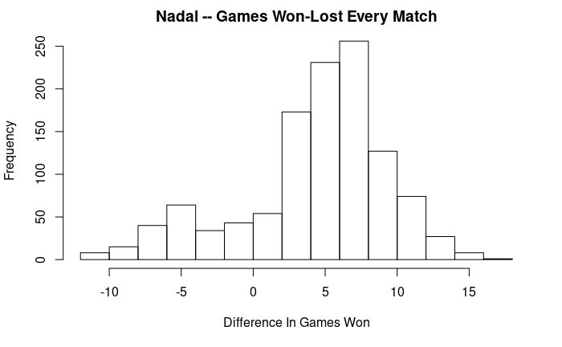

```r
RNmatches <- read.csv(file = 'Tennis Player Matches/3RNMatches.csv')
gamedifferencepermatch <- RNmatches[["GameDifference"]]
hist(gamedifferencepermatch, xlab = "Difference In Games Won", main = "Nadal -- Games Won-Lost Every Match", breaks = 15)
```

Calculate “Variability” And Notice Distribution Shape

```r
m = mean(gamedifferencepermatch)
stdv = sd(gamedifferencepermatch)

summary(gamedifferencepermatch)
```

```
   Min. 1st Qu.  Median    Mean 3rd Qu.    Max.
-12.000   3.000   6.000   4.842   8.000  17.000
```

```r
print(paste0("Standard Deviation: ", stdv))
```

```
[1] "Standard Deviation: 5.11033557083605"
```

## Ivan Lendl

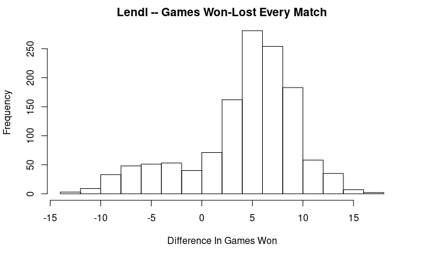

```r
ILmatches <- read.csv(file = 'Tennis Player Matches/4ILMatches.csv')
gamedifferencepermatch <- ILmatches[["GameDifference"]]
hist(gamedifferencepermatch, xlab = "Difference In Games Won", main = "Lendl -- Games Won-Lost Every Match", breaks = 15)
```

Calculate “Variability” And Notice Distribution Shape

```r
m = mean(gamedifferencepermatch)
stdv = sd(gamedifferencepermatch)

summary(gamedifferencepermatch)
```

```
   Min. 1st Qu.  Median    Mean 3rd Qu.    Max.
-13.000   3.000   6.000   4.713   8.000  18.000
```

```r
print(paste0("Standard Deviation: ", stdv))
```

```
[1] "Standard Deviation: 5.34604513444406"
```

## Jimmy Connors

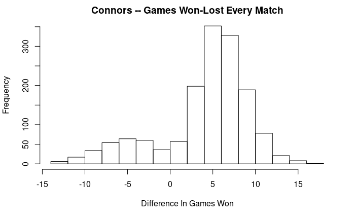

```r
JCmatches <- read.csv(file = 'Tennis Player Matches/5JCMatches.csv')
gamedifferencepermatch <- JCmatches[["GameDifference"]]
hist(gamedifferencepermatch, xlab = "Difference In Games Won", main = "Connors -- Games Won-Lost Every Match", breaks = 15)
```

Calculate “Variability” And Notice Distribution Shape

```r
m = mean(gamedifferencepermatch)
stdv = sd(gamedifferencepermatch)

summary(gamedifferencepermatch)
```

```
   Min. 1st Qu.  Median    Mean 3rd Qu.    Max.
 -14.00    3.00    6.00    4.65    8.00   17.00
```

```r
print(paste0("Standard Deviation: ", stdv))
```

```
[1] "Standard Deviation: 5.28898042288614"
```

## Pete Sampras

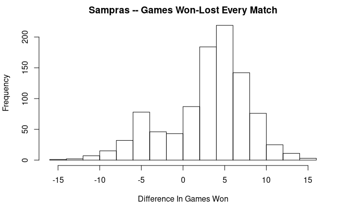

```r
PSmatches <- read.csv(file = 'Tennis Player Matches/6PSMatches.csv')
gamedifferencepermatch <- PSmatches[["GameDifference"]]
hist(gamedifferencepermatch, xlab = "Difference In Games Won", main = "Sampras -- Games Won-Lost Every Match", breaks = 15)
```

Calculate “Variability” And Notice Distribution Shape

```r
m = mean(gamedifferencepermatch)
stdv = sd(gamedifferencepermatch)

summary(gamedifferencepermatch)
```

```
   Min. 1st Qu.  Median    Mean 3rd Qu.    Max.
-15.000   1.000   4.000   3.399   7.000  16.000
```

```r
print(paste0("Standard Deviation: ", stdv))
```

```
[1] "Standard Deviation: 4.90347635797912"
```

## John McEnroe

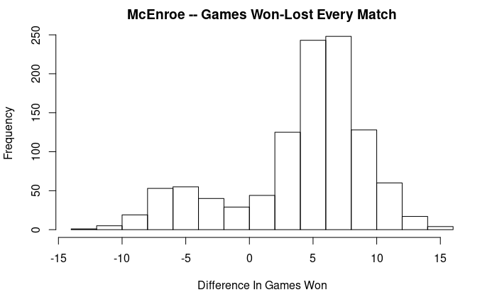

```r
JMmatches <- read.csv(file = 'Tennis Player Matches/7JMMatches.csv')
gamedifferencepermatch <- JMmatches[["GameDifference"]]
hist(gamedifferencepermatch, xlab = "Difference In Games Won", main = "McEnroe -- Games Won-Lost Every Match", breaks = 15)
```

Calculate “Variability” And Notice Distribution Shape

```r
m = mean(gamedifferencepermatch)
stdv = sd(gamedifferencepermatch)

summary(gamedifferencepermatch)
```

```
   Min. 1st Qu.  Median    Mean 3rd Qu.    Max.
-13.000   3.000   6.000   4.595   8.000  15.000
```

```r
print(paste0("Standard Deviation: ", stdv))
```

```
[1] "Standard Deviation: 5.1580742185318"
```

## Bjorn Borg

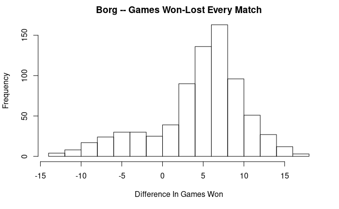

```r
BBmatches <- read.csv(file = 'Tennis Player Matches/8BBMatches.csv')
gamedifferencepermatch <- BBmatches[["GameDifference"]]
hist(gamedifferencepermatch, xlab = "Difference In Games Won", main = "Borg -- Games Won-Lost Every Match", breaks = 15)
```

Calculate “Variability” And Notice Distribution Shape

```r
m = mean(gamedifferencepermatch)
stdv = sd(gamedifferencepermatch)

summary(gamedifferencepermatch)
```

```
   Min. 1st Qu.  Median    Mean 3rd Qu.    Max.
 -14.00    3.00    6.00    5.03    8.50   17.00
```

```r
print(paste0("Standard Deviation: ", stdv))
```

```
[1] "Standard Deviation: 5.69334612535673"
```

## Andre Agassi

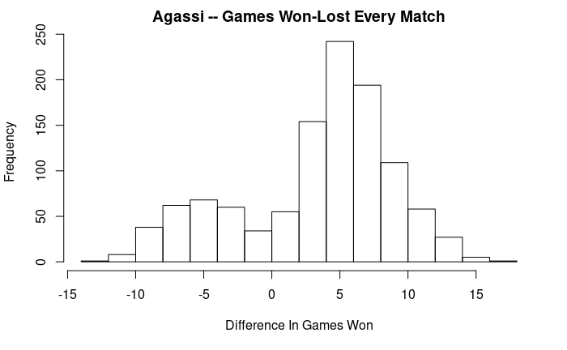

```r
AAmatches <- read.csv(file = 'Tennis Player Matches/9AAMatches.csv')
gamedifferencepermatch <- AAmatches[["GameDifference"]]
hist(gamedifferencepermatch, xlab = "Difference In Games Won", main = "Agassi -- Games Won-Lost Every Match", breaks = 15)
```

Calculate “Variability” And Notice Distribution Shape

```r
m = mean(gamedifferencepermatch)
stdv = sd(gamedifferencepermatch)

summary(gamedifferencepermatch)
```

```
   Min. 1st Qu.  Median    Mean 3rd Qu.    Max.
-13.000   1.000   5.000   3.863   8.000  17.000
```

```r
print(paste0("Standard Deviation: ", stdv))
```

```
[1] "Standard Deviation: 5.662244099766"
```

## Borris Becker

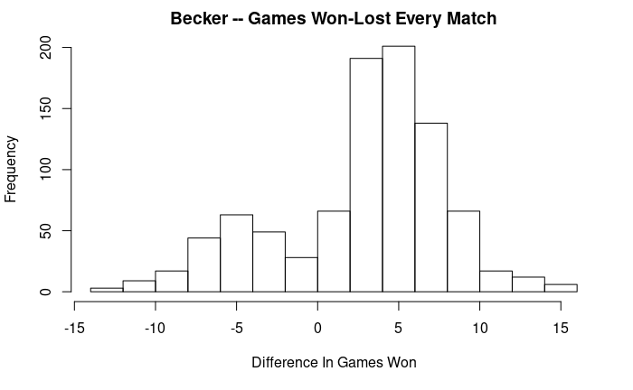

```r
BKmatches <- read.csv(file = 'Tennis Player Matches/10BBckMatches.csv')
gamedifferencepermatch <- BKmatches[["GameDifference"]]
hist(gamedifferencepermatch, xlab = "Difference In Games Won", main = "Becker -- Games Won-Lost Every Match", breaks = 15)
```

Calculate “Variability” And Notice Distribution Shape

```r
m = mean(gamedifferencepermatch)
stdv = sd(gamedifferencepermatch)

summary(gamedifferencepermatch)
```

```
   Min. 1st Qu.  Median    Mean 3rd Qu.    Max.
-13.000   1.000   4.000   3.341   7.000  16.000
```

```r
print(paste0("Standard Deviation: ", stdv))
```

```
[1] "Standard Deviation: 5.20370473981154"
```

Distribution Shape:

I noticed that the distributions seen above all had a very similar shape. One tall hump on the positive side of 0, and a smaller flat hump on the negative side. I think the reason for these two humps is because a player can either win or lose a match. If he won a match, he would most likely have won more games than his opponent and vice versa. Overall the distributions are very skewed left which is to be expected considering the players win/loss ratio. Because all the shapes are so similar, the only way I really compared them was by the height of the humps (# games won) in which case Federer is the winner.

Normalize (Take Z-Scores)

```r
zs = c(4.80976431016085, 4.92418661319707, 5.11033557083605, 5.34604513444406, 5.28898042288614, 4.90347635797912, 5.1580742185318, 5.69334612535673, 5.662244099766, 5.20370473981154)
names(zs) = overallstats[["PlayerName"]]

scale(zs)
```

```
                     [,1]
Roger Federer  -1.3330217
Novak Djokovic -0.9519427
Rafael Nadal   -0.3319809
Ivan Lendl      0.4530405
Jimmy Connors   0.2629887
Pete Sampras   -1.0209174
John McEnroe   -0.1729893
Bjorn Borg      1.6097128
Andre Agassi    1.5061287
Borris Becker  -0.0210186
attr(,"scaled:center")
[1] 5.210016
attr(,"scaled:scale")
[1] 0.3002588
```

# Final Tallying

Weights I Determined: Weight For Grand Slam Titles - 0.9 Weight For Big Titles - 0.8 Weight For Games Won - 0.7 Weight For Matches Won - 0.9 Weight For Weeks at #1 - 0.9 Weight For Game Winning Consistency(sd) - 0.5

Grand Slams, Big Titles, Games Won, Matches Won, Weeks at #1, Game Winning Consistency Roger Federer -SUI 1.5508857 * 0.9 + 1.30636863 * 0.8 + 1.6581025 * 0.7 + 1.4562820 * 0.9 + 1.08405782 * 0.9 - 1.3330217 * 0.5 = 5.221358772 Novak Djokovic -SRB 0.9834885 * 0.9 + 1.46568187 * 0.8 - 0.1711528 * 0.7 - 0.1005984 * 0.9 + 0.80404288 * 0.9 - 0.9519427 * 0.5 = 2.095006868 Rafael Nadal -ESP 1.3617533 * 0.9 + 1.38602525 * 0.8 + 0.0559132 * 0.7 + 0.2682625 * 0.9 + 0.07400395 * 0.9 - 0.3319809 * 0.5 = 2.515586765 Ivan Lendl -USA -0.7187031 * 0.9 - 0.04779397 * 0.8 + 0.6506236 * 0.7 + 0.6658658 * 0.9 + 0.68403648 * 0.9 + 0.4530405 * 0.5 = 1.211800856 Jimmy Connors -USA -0.7187031 * 0.9 - 0.76470359 * 0.8 + 1.3992183 * 0.7 + 1.5472996 * 0.9 + 0.65403488 * 0.9 + 0.2629887 * 0.5 = 1.83355253 Pete Sampras -USA 0.4160913 * 0.9 - 0.44607709 * 0.8 - 0.6125576 * 0.7 - 0.8143682 * 0.9 + 0.84404502 * 0.9 - 1.0209174 * 0.5 = -0.894919384 John McEnroe -USA -0.9078355 * 0.9 - 0.28676384 * 0.8 - 0.3640866 * 0.7 - 0.2443105 * 0.9 - 0.31601685 * 0.9 - 0.1729893 * 0.5 = -1.892112907 Bjorn Borg -SWE -0.1513059 * 0.9 - 0.68504696 * 0.8 - 1.5908215 * 0.7 - 1.4275396 * 0.9 - 0.92604939 * 0.9 + 1.6097128 * 0.5 = -3.111161619 Andre Agassi -USA -0.7187031 * 0.9 - 0.84436021 * 0.8 - 0.1430950 * 0.7 - 0.2970049 * 0.9 - 1.00605366 * 0.9 + 1.5061287 * 0.5 = -1.842175812 Borris Becker -GER -1.0969679 * 0.9 - 1.08333008 * 0.8 - 0.8821442 * 0.7 - 1.0538883 * 0.9 - 1.89610113 * 0.9 - 0.0210186 * 0.5 = -5.136935901

# Visualization Of Ranking

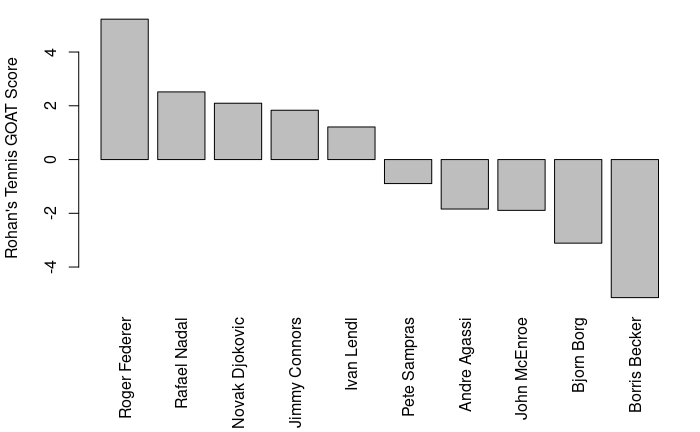

```r
players = c(5.221358772, 2.095006868, 2.515586765, 1.211800856, 1.83355253, -0.894919384, -1.892112907, -3.111161619, -1.842175812, -5.136935901)
names(players) = overallstats[["PlayerName"]]
par(mar=c(7, 4.1, 1, 1))
barplot(sort(players, decreasing = TRUE), las=3, ylab="Rohan's Tennis GOAT Score")
```

So in the end, Roger Federer is officially the GOAT of Mens Tennis (according to me). I actually got surprisingly similar results to the website that I got my data from which also has a GOAT ranking.